# Risk Factor Analysis

## Outcome Variable

**Outcome Variable:** ever_sstunted

## Predictor Variables

**Intervention Variable:** nrooms

**Adjustment Set:**

unadjusted

## Stratifying Variables

The analysis was stratified on these variable(s):

- agecat
- studyid
- country

## Data Summary

| agecat | studyid | country | nrooms | ever_sstunted | n_cell | n |
| --- | --- | --- | --- | --- | --- | --- |
| 0-24 months | CMC-V-BCS-2002 | INDIA | 4+ | 0 | 5 | 373 |
| 0-24 months | CMC-V-BCS-2002 | INDIA | 4+ | 1 | 9 | 373 |
| 0-24 months | CMC-V-BCS-2002 | INDIA | 1 | 0 | 68 | 373 |
| 0-24 months | CMC-V-BCS-2002 | INDIA | 1 | 1 | 134 | 373 |
| 0-24 months | CMC-V-BCS-2002 | INDIA | 2 | 0 | 40 | 373 |
| 0-24 months | CMC-V-BCS-2002 | INDIA | 2 | 1 | 66 | 373 |
| 0-24 months | CMC-V-BCS-2002 | INDIA | 3 | 0 | 23 | 373 |
| 0-24 months | CMC-V-BCS-2002 | INDIA | 3 | 1 | 28 | 373 |
| 0-24 months | COHORTS | INDIA | 4+ | 0 | 102 | 5374 |
| 0-24 months | COHORTS | INDIA | 4+ | 1 | 4 | 5374 |
| 0-24 months | COHORTS | INDIA | 1 | 0 | 2917 | 5374 |
| 0-24 months | COHORTS | INDIA | 1 | 1 | 602 | 5374 |
| 0-24 months | COHORTS | INDIA | 2 | 0 | 1440 | 5374 |
| 0-24 months | COHORTS | INDIA | 2 | 1 | 114 | 5374 |
| 0-24 months | COHORTS | INDIA | 3 | 0 | 178 | 5374 |
| 0-24 months | COHORTS | INDIA | 3 | 1 | 17 | 5374 |
| 0-24 months | CONTENT | PERU | 4+ | 0 | 75 | 215 |
| 0-24 months | CONTENT | PERU | 4+ | 1 | 3 | 215 |
| 0-24 months | CONTENT | PERU | 1 | 0 | 42 | 215 |
| 0-24 months | CONTENT | PERU | 1 | 1 | 2 | 215 |
| 0-24 months | CONTENT | PERU | 2 | 0 | 50 | 215 |
| 0-24 months | CONTENT | PERU | 2 | 1 | 4 | 215 |
| 0-24 months | CONTENT | PERU | 3 | 0 | 38 | 215 |
| 0-24 months | CONTENT | PERU | 3 | 1 | 1 | 215 |
| 0-24 months | GMS-Nepal | NEPAL | 4+ | 0 | 241 | 698 |
| 0-24 months | GMS-Nepal | NEPAL | 4+ | 1 | 82 | 698 |
| 0-24 months | GMS-Nepal | NEPAL | 1 | 0 | 37 | 698 |
| 0-24 months | GMS-Nepal | NEPAL | 1 | 1 | 12 | 698 |
| 0-24 months | GMS-Nepal | NEPAL | 2 | 0 | 111 | 698 |
| 0-24 months | GMS-Nepal | NEPAL | 2 | 1 | 34 | 698 |

[output cut: 194 more lines]

The following strata were considered:

- agecat: 0-24 months, studyid: CMC-V-BCS-2002, country: INDIA
- agecat: 0-24 months, studyid: COHORTS, country: INDIA
- agecat: 0-24 months, studyid: CONTENT, country: PERU
- agecat: 0-24 months, studyid: GMS-Nepal, country: NEPAL
- agecat: 0-24 months, studyid: IRC, country: INDIA
- agecat: 0-24 months, studyid: MAL-ED, country: BANGLADESH
- agecat: 0-24 months, studyid: MAL-ED, country: BRAZIL
- agecat: 0-24 months, studyid: MAL-ED, country: INDIA
- agecat: 0-24 months, studyid: MAL-ED, country: NEPAL
- agecat: 0-24 months, studyid: MAL-ED, country: PERU
- agecat: 0-24 months, studyid: MAL-ED, country: SOUTH AFRICA
- agecat: 0-24 months, studyid: MAL-ED, country: TANZANIA, UNITED REPUBLIC OF
- agecat: 0-24 months, studyid: NIH-Crypto, country: BANGLADESH
- agecat: 0-24 months, studyid: PROVIDE, country: BANGLADESH
- agecat: 0-6 months, studyid: CMC-V-BCS-2002, country: INDIA
- agecat: 0-6 months, studyid: COHORTS, country: INDIA
- agecat: 0-6 months, studyid: CONTENT, country: PERU
- agecat: 0-6 months, studyid: GMS-Nepal, country: NEPAL
- agecat: 0-6 months, studyid: IRC, country: INDIA
- agecat: 0-6 months, studyid: MAL-ED, country: BANGLADESH
- agecat: 0-6 months, studyid: MAL-ED, country: BRAZIL
- agecat: 0-6 months, studyid: MAL-ED, country: INDIA
- agecat: 0-6 months, studyid: MAL-ED, country: NEPAL
- agecat: 0-6 months, studyid: MAL-ED, country: PERU
- agecat: 0-6 months, studyid: MAL-ED, country: SOUTH AFRICA
- agecat: 0-6 months, studyid: MAL-ED, country: TANZANIA, UNITED REPUBLIC OF
- agecat: 0-6 months, studyid: NIH-Crypto, country: BANGLADESH
- agecat: 0-6 months, studyid: PROVIDE, country: BANGLADESH

### Dropped Strata

Some strata were dropped due to rare outcomes:

- agecat: 0-24 months, studyid: COHORTS, country: INDIA
- agecat: 0-24 months, studyid: CONTENT, country: PERU
- agecat: 0-24 months, studyid: IRC, country: INDIA
- agecat: 0-24 months, studyid: MAL-ED, country: BANGLADESH
- agecat: 0-24 months, studyid: MAL-ED, country: BRAZIL
- agecat: 0-24 months, studyid: MAL-ED, country: INDIA
- agecat: 0-24 months, studyid: MAL-ED, country: NEPAL
- agecat: 0-24 months, studyid: MAL-ED, country: SOUTH AFRICA
- agecat: 0-24 months, studyid: PROVIDE, country: BANGLADESH
- agecat: 0-6 months, studyid: CMC-V-BCS-2002, country: INDIA
- agecat: 0-6 months, studyid: COHORTS, country: INDIA
- agecat: 0-6 months, studyid: CONTENT, country: PERU
- agecat: 0-6 months, studyid: IRC, country: INDIA
- agecat: 0-6 months, studyid: MAL-ED, country: BANGLADESH
- agecat: 0-6 months, studyid: MAL-ED, country: BRAZIL
- agecat: 0-6 months, studyid: MAL-ED, country: INDIA
- agecat: 0-6 months, studyid: MAL-ED, country: NEPAL
- agecat: 0-6 months, studyid: MAL-ED, country: SOUTH AFRICA
- agecat: 0-6 months, studyid: MAL-ED, country: TANZANIA, UNITED REPUBLIC OF
- agecat: 0-6 months, studyid: PROVIDE, country: BANGLADESH

## Methods Detail

We’re interested in the causal parameters $E[Y_a]$ for all values of $a \in \mathcal{A}$. These parameters represent the mean outcome if, possibly contrary to fact, we intervened to set all units to have $A=a$. Under the randomization and positivity assumptions, these are identified by the statistical parameters $\psi_a=E_W[E_{Y|A,W}(Y|A=a,W)]$. In addition, we’re interested in the mean of $Y$, $E[Y]$ under no intervention (the observed mean). We will estimate these parameters by using SuperLearner to fit the relevant likelihood factors – $E_{Y|A,W}(Y|A=a,W)$ and $p(A=a|W)$, and then updating our likelihood fit using a joint TMLE.

For unadjusted analyses ($W=\{\}$), initial likelihoods were estimated using Lrnr_glm to estimate the simple $E(Y|A)$ and Lrnr_mean to estimate $p(A)$. For adjusted analyses, a small library containing Lrnr_glmnet, Lrnr_xgboost, and Lrnr_mean was used.

Having estimated these parameters, we will then use the delta method to estimate relative risks and attributable risks relative to a prespecified baseline level of $A$.

# Results Detail

## Results Plots

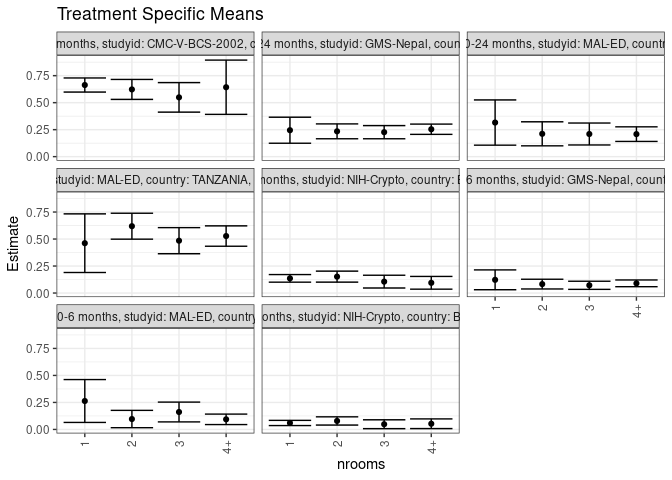

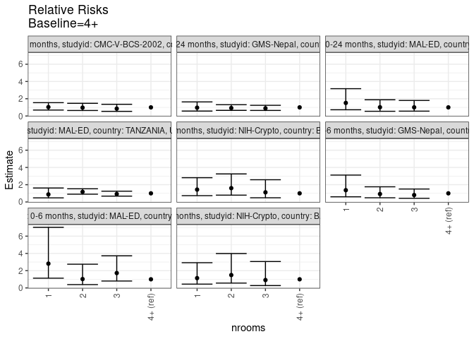

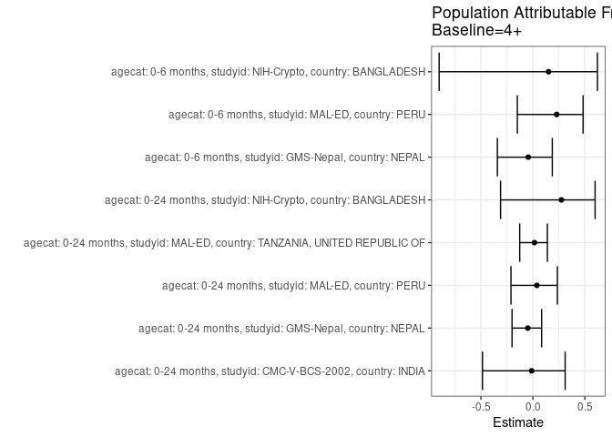

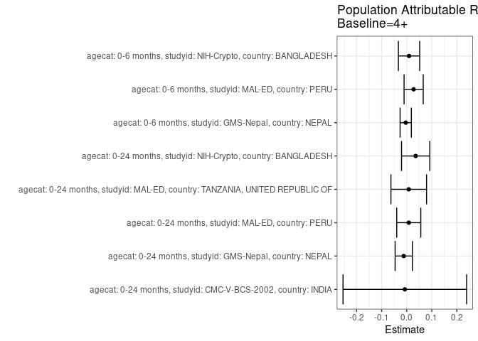

## Results Table

### Parameter: TSM

| agecat | studyid | country | intervention_level | baseline_level | estimate | ci_lower | ci_upper |
| --- | --- | --- | --- | --- | --- | --- | --- |
| 0-24 months | CMC-V-BCS-2002 | INDIA | 4+ | NA | 0.6428571 | 0.3915266 | 0.8941877 |
| 0-24 months | CMC-V-BCS-2002 | INDIA | 1 | NA | 0.6633663 | 0.5981118 | 0.7286209 |
| 0-24 months | CMC-V-BCS-2002 | INDIA | 2 | NA | 0.6226415 | 0.5302410 | 0.7150420 |
| 0-24 months | CMC-V-BCS-2002 | INDIA | 3 | NA | 0.5490196 | 0.4122723 | 0.6857669 |
| 0-24 months | GMS-Nepal | NEPAL | 4+ | NA | 0.2538700 | 0.2063724 | 0.3013675 |
| 0-24 months | GMS-Nepal | NEPAL | 1 | NA | 0.2448980 | 0.1244064 | 0.3653896 |
| 0-24 months | GMS-Nepal | NEPAL | 2 | NA | 0.2344828 | 0.1654733 | 0.3034922 |
| 0-24 months | GMS-Nepal | NEPAL | 3 | NA | 0.2265193 | 0.1654958 | 0.2875429 |
| 0-24 months | MAL-ED | PERU | 4+ | NA | 0.2086331 | 0.1409592 | 0.2763070 |
| 0-24 months | MAL-ED | PERU | 1 | NA | 0.3157895 | 0.1063952 | 0.5251837 |
| 0-24 months | MAL-ED | PERU | 2 | NA | 0.2115385 | 0.1003317 | 0.3227452 |
| 0-24 months | MAL-ED | PERU | 3 | NA | 0.2096774 | 0.1081625 | 0.3111924 |
| 0-24 months | MAL-ED | TANZANIA, UNITED REPUBLIC OF | 4+ | NA | 0.5277778 | 0.4334357 | 0.6221198 |
| 0-24 months | MAL-ED | TANZANIA, UNITED REPUBLIC OF | 1 | NA | 0.4615385 | 0.1900021 | 0.7330749 |
| 0-24 months | MAL-ED | TANZANIA, UNITED REPUBLIC OF | 2 | NA | 0.6190476 | 0.4988916 | 0.7392036 |
| 0-24 months | MAL-ED | TANZANIA, UNITED REPUBLIC OF | 3 | NA | 0.4848485 | 0.3640346 | 0.6056624 |
| 0-24 months | NIH-Crypto | BANGLADESH | 4+ | NA | 0.0947368 | 0.0358091 | 0.1536646 |
| 0-24 months | NIH-Crypto | BANGLADESH | 1 | NA | 0.1358696 | 0.1008378 | 0.1709013 |
| 0-24 months | NIH-Crypto | BANGLADESH | 2 | NA | 0.1518325 | 0.1009063 | 0.2027587 |
| 0-24 months | NIH-Crypto | BANGLADESH | 3 | NA | 0.1057692 | 0.0466236 | 0.1649148 |
| 0-6 months | GMS-Nepal | NEPAL | 4+ | NA | 0.0897833 | 0.0585852 | 0.1209814 |
| 0-6 months | GMS-Nepal | NEPAL | 1 | NA | 0.1224490 | 0.0305998 | 0.2142981 |
| 0-6 months | GMS-Nepal | NEPAL | 2 | NA | 0.0827586 | 0.0378816 | 0.1276356 |
| 0-6 months | GMS-Nepal | NEPAL | 3 | NA | 0.0718232 | 0.0341816 | 0.1094648 |
| 0-6 months | MAL-ED | PERU | 4+ | NA | 0.0935252 | 0.0450318 | 0.1420186 |
| 0-6 months | MAL-ED | PERU | 1 | NA | 0.2631579 | 0.0647922 | 0.4615236 |
| 0-6 months | MAL-ED | PERU | 2 | NA | 0.0961538 | 0.0158795 | 0.1764282 |
| 0-6 months | MAL-ED | PERU | 3 | NA | 0.1612903 | 0.0695707 | 0.2530099 |
| 0-6 months | NIH-Crypto | BANGLADESH | 4+ | NA | 0.0526316 | 0.0076996 | 0.0975636 |
| 0-6 months | NIH-Crypto | BANGLADESH | 1 | NA | 0.0597826 | 0.0355437 | 0.0840215 |
| 0-6 months | NIH-Crypto | BANGLADESH | 2 | NA | 0.0785340 | 0.0403584 | 0.1167097 |
| 0-6 months | NIH-Crypto | BANGLADESH | 3 | NA | 0.0480769 | 0.0069347 | 0.0892191 |

### Parameter: E(Y)

| agecat | studyid | country | intervention_level | baseline_level | estimate | ci_lower | ci_upper |
| --- | --- | --- | --- | --- | --- | --- | --- |
| 0-24 months | CMC-V-BCS-2002 | INDIA | NA | NA | 0.6353887 | 0.5864772 | 0.6843003 |
| 0-24 months | GMS-Nepal | NEPAL | NA | NA | 0.2421203 | 0.2103189 | 0.2739218 |
| 0-24 months | MAL-ED | PERU | NA | NA | 0.2169118 | 0.1678424 | 0.2659811 |
| 0-24 months | MAL-ED | TANZANIA, UNITED REPUBLIC OF | NA | NA | 0.5360000 | 0.4740573 | 0.5979427 |
| 0-24 months | NIH-Crypto | BANGLADESH | NA | NA | 0.1306069 | 0.1066024 | 0.1546113 |
| 0-6 months | GMS-Nepal | NEPAL | NA | NA | 0.0859599 | 0.0651504 | 0.1067694 |
| 0-6 months | MAL-ED | PERU | NA | NA | 0.1213235 | 0.0824503 | 0.1601967 |
| 0-6 months | NIH-Crypto | BANGLADESH | NA | NA | 0.0620053 | 0.0448256 | 0.0791849 |

### Parameter: RR

| agecat | studyid | country | intervention_level | baseline_level | estimate | ci_lower | ci_upper |
| --- | --- | --- | --- | --- | --- | --- | --- |
| 0-24 months | CMC-V-BCS-2002 | INDIA | 4+ | 4+ | 1.0000000 | 1.0000000 | 1.000000 |
| 0-24 months | CMC-V-BCS-2002 | INDIA | 1 | 4+ | 1.0319032 | 0.6895341 | 1.544266 |
| 0-24 months | CMC-V-BCS-2002 | INDIA | 2 | 4+ | 0.9685535 | 0.6375466 | 1.471415 |
| 0-24 months | CMC-V-BCS-2002 | INDIA | 3 | 4+ | 0.8540305 | 0.5372200 | 1.357671 |
| 0-24 months | GMS-Nepal | NEPAL | 4+ | 4+ | 1.0000000 | 1.0000000 | 1.000000 |
| 0-24 months | GMS-Nepal | NEPAL | 1 | 4+ | 0.9646590 | 0.5698625 | 1.632968 |
| 0-24 months | GMS-Nepal | NEPAL | 2 | 4+ | 0.9236333 | 0.6516941 | 1.309047 |
| 0-24 months | GMS-Nepal | NEPAL | 3 | 4+ | 0.8922652 | 0.6427600 | 1.238623 |
| 0-24 months | MAL-ED | PERU | 4+ | 4+ | 1.0000000 | 1.0000000 | 1.000000 |
| 0-24 months | MAL-ED | PERU | 1 | 4+ | 1.5136116 | 0.7234893 | 3.166626 |
| 0-24 months | MAL-ED | PERU | 2 | 4+ | 1.0139257 | 0.5466799 | 1.880525 |
| 0-24 months | MAL-ED | PERU | 3 | 4+ | 1.0050056 | 0.5611477 | 1.799947 |
| 0-24 months | MAL-ED | TANZANIA, UNITED REPUBLIC OF | 4+ | 4+ | 1.0000000 | 1.0000000 | 1.000000 |
| 0-24 months | MAL-ED | TANZANIA, UNITED REPUBLIC OF | 1 | 4+ | 0.8744939 | 0.4728415 | 1.617328 |
| 0-24 months | MAL-ED | TANZANIA, UNITED REPUBLIC OF | 2 | 4+ | 1.1729323 | 0.9008990 | 1.527108 |
| 0-24 months | MAL-ED | TANZANIA, UNITED REPUBLIC OF | 3 | 4+ | 0.9186603 | 0.6760401 | 1.248353 |
| 0-24 months | NIH-Crypto | BANGLADESH | 4+ | 4+ | 1.0000000 | 1.0000000 | 1.000000 |
| 0-24 months | NIH-Crypto | BANGLADESH | 1 | 4+ | 1.4341787 | 0.7314377 | 2.812090 |
| 0-24 months | NIH-Crypto | BANGLADESH | 2 | 4+ | 1.6026760 | 0.7905631 | 3.249039 |
| 0-24 months | NIH-Crypto | BANGLADESH | 3 | 4+ | 1.1164530 | 0.4837121 | 2.576878 |
| 0-6 months | GMS-Nepal | NEPAL | 4+ | 4+ | 1.0000000 | 1.0000000 | 1.000000 |
| 0-6 months | GMS-Nepal | NEPAL | 1 | 4+ | 1.3638283 | 0.5966754 | 3.117319 |
| 0-6 months | GMS-Nepal | NEPAL | 2 | 4+ | 0.9217598 | 0.4840749 | 1.755185 |
| 0-6 months | GMS-Nepal | NEPAL | 3 | 4+ | 0.7999619 | 0.4265575 | 1.500241 |
| 0-6 months | MAL-ED | PERU | 4+ | 4+ | 1.0000000 | 1.0000000 | 1.000000 |
| 0-6 months | MAL-ED | PERU | 1 | 4+ | 2.8137652 | 1.1270690 | 7.024658 |
| 0-6 months | MAL-ED | PERU | 2 | 4+ | 1.0281065 | 0.3847940 | 2.746932 |
| 0-6 months | MAL-ED | PERU | 3 | 4+ | 1.7245658 | 0.7988469 | 3.723025 |
| 0-6 months | NIH-Crypto | BANGLADESH | 4+ | 4+ | 1.0000000 | 1.0000000 | 1.000000 |
| 0-6 months | NIH-Crypto | BANGLADESH | 1 | 4+ | 1.1358696 | 0.4414468 | 2.922661 |
| 0-6 months | NIH-Crypto | BANGLADESH | 2 | 4+ | 1.4921466 | 0.5586757 | 3.985320 |
| 0-6 months | NIH-Crypto | BANGLADESH | 3 | 4+ | 0.9134615 | 0.2727256 | 3.059530 |

### Parameter: PAR

| agecat | studyid | country | intervention_level | baseline_level | estimate | ci_lower | ci_upper |
| --- | --- | --- | --- | --- | --- | --- | --- |
| 0-24 months | CMC-V-BCS-2002 | INDIA | 4+ | NA | -0.0074684 | -0.2540807 | 0.2391439 |
| 0-24 months | GMS-Nepal | NEPAL | 4+ | NA | -0.0117496 | -0.0460921 | 0.0225928 |
| 0-24 months | MAL-ED | PERU | 4+ | NA | 0.0082787 | -0.0397503 | 0.0563076 |
| 0-24 months | MAL-ED | TANZANIA, UNITED REPUBLIC OF | 4+ | NA | 0.0082222 | -0.0628225 | 0.0792669 |
| 0-24 months | NIH-Crypto | BANGLADESH | 4+ | NA | 0.0358700 | -0.0205062 | 0.0922463 |
| 0-6 months | GMS-Nepal | NEPAL | 4+ | NA | -0.0038234 | -0.0263078 | 0.0186610 |
| 0-6 months | MAL-ED | PERU | 4+ | NA | 0.0277983 | -0.0104018 | 0.0659985 |
| 0-6 months | NIH-Crypto | BANGLADESH | 4+ | NA | 0.0093737 | -0.0331466 | 0.0518939 |

### Parameter: PAF

| agecat | studyid | country | intervention_level | baseline_level | estimate | ci_lower | ci_upper |
| --- | --- | --- | --- | --- | --- | --- | --- |
| 0-24 months | CMC-V-BCS-2002 | INDIA | 4+ | NA | -0.0117541 | -0.4848403 | 0.3106018 |
| 0-24 months | GMS-Nepal | NEPAL | 4+ | NA | -0.0485280 | -0.2003558 | 0.0840957 |
| 0-24 months | MAL-ED | PERU | 4+ | NA | 0.0381661 | -0.2107165 | 0.2358868 |
| 0-24 months | MAL-ED | TANZANIA, UNITED REPUBLIC OF | 4+ | NA | 0.0153400 | -0.1265586 | 0.1393654 |
| 0-24 months | NIH-Crypto | BANGLADESH | 4+ | NA | 0.2746411 | -0.3110170 | 0.5986738 |
| 0-6 months | GMS-Nepal | NEPAL | 4+ | NA | -0.0444788 | -0.3414847 | 0.1867697 |
| 0-6 months | MAL-ED | PERU | 4+ | NA | 0.2291258 | -0.1495646 | 0.4830677 |
| 0-6 months | NIH-Crypto | BANGLADESH | 4+ | NA | 0.1511758 | -0.9014990 | 0.6210871 |